# algebraic.dist: Examples

## Introduction

To demonstrate the R package `algebraic.dist`, we consider the multivariate normal distribution (MVN) and its empirical approximation.

We start by loading the package:

```r
library(algebraic.dist)
```

## Defining the data generating process

We define the parameters of the data generating process (DGP) with:

```r
# we define the parameters of the MVN
M <- mvn(mu = 1:5, sigma = diag(1:5))
print(M)
```

```
#> Multivariate normal distribution with mean:
#> [1] 1 2 3 4 5
#> and variance-covariance matrix:
#>      [,1] [,2] [,3] [,4] [,5]
#> [1,]    1    0    0    0    0
#> [2,]    0    2    0    0    0
#> [3,]    0    0    3    0    0
#> [4,]    0    0    0    4    0
#> [5,]    0    0    0    0    5
```

Each observation is an i.i.d. vector from the MVN. We sample from the MVN with:

```r
# we generate a sample of size n
n <- 100000

# we sample from the MVN
data <- sampler(M)(n)
```

We have a sample of size $n=100000$ from the DGP. We show some observations from this sample with:

```r
head(data, n=6)
```

```
#>        [,1]    [,2]   [,3]   [,4] [,5]
#> [1,]  0.281  2.7628  5.537 -0.545 7.16
#> [2,]  2.940  2.3338 -0.262  5.232 6.59
#> [3,]  3.544 -0.0658  1.715  4.112 4.44
#> [4,]  0.780  4.3374  3.471  1.604 2.65
#> [5,]  1.567  5.1359  1.562  7.002 1.75
#> [6,] -0.504  1.7233  2.871  2.730 3.57
```

Now, we also construct a empirical distribution from the sample with:

```r
emp <- empirical_dist(data)
print(emp)
```

```
#> Empirical Distribution
#> Mean:
#> [1] 1.01 2.00 3.00 4.00 5.00
#> Covariance:
#>          [,1]     [,2]     [,3]      [,4]      [,5]
#> [1,]  1.00467  0.00339 -0.00843  0.002242 -0.005110
#> [2,]  0.00339  2.00599 -0.00139  0.009747  0.011769
#> [3,] -0.00843 -0.00139  2.98459 -0.003842 -0.025963
#> [4,]  0.00224  0.00975 -0.00384  3.991147 -0.000719
#> [5,] -0.00511  0.01177 -0.02596 -0.000719  4.978949
#> Number of observations: 100000
```

Let’s show the supports of the empirical distribution and the MVN:

```r
# generate a data frame with the dimension, supremum,
# and infimum of the MVN and empirical distribution
df <- data.frame(supremum.mvn = supremum(sup(M)),
                 supremum.emp = supremum(sup(emp)),
                 infimum.mvn = infimum(sup(M)),
                 infimum.emp = infimum(sup(emp)))
row.names(df) <- paste0("param",1:dim(sup(M)))
print(df)
```

```
#>        supremum.mvn supremum.emp infimum.mvn infimum.emp
#> param1          Inf         5.69        -Inf       -3.52
#> param2          Inf         8.63        -Inf       -3.85
#> param3          Inf        10.47        -Inf       -3.98
#> param4          Inf        12.90        -Inf       -4.37
#> param5          Inf        14.94        -Inf       -4.84
```

Let’s compare the mean and covariance-variance matrices of both the MVN and the empirical distribution of the MVN. First, let’s look at the means.

```r
mean(M)
```

```
#> [1] 1 2 3 4 5
```

```r
mean(emp)
```

```
#> [1] 1.01 2.00 3.00 4.00 5.00
```

As expected, pretty close. Now let’s look at the variance-covariance:

```r
vcov(M)
```

```
#>      [,1] [,2] [,3] [,4] [,5]
#> [1,]    1    0    0    0    0
#> [2,]    0    2    0    0    0
#> [3,]    0    0    3    0    0
#> [4,]    0    0    0    4    0
#> [5,]    0    0    0    0    5
```

```r
vcov(emp)
```

```
#>          [,1]     [,2]     [,3]      [,4]      [,5]
#> [1,]  1.00467  0.00339 -0.00843  0.002242 -0.005110
#> [2,]  0.00339  2.00599 -0.00139  0.009747  0.011769
#> [3,] -0.00843 -0.00139  2.98459 -0.003842 -0.025963
#> [4,]  0.00224  0.00975 -0.00384  3.991147 -0.000719
#> [5,] -0.00511  0.01177 -0.02596 -0.000719  4.978949
```

The true variances of the population defined by the MVN $M$ is the diagonal of the variance-covariance matrix:

```r
diag(vcov(M))
```

```
#> [1] 1 2 3 4 5
```

Let’s compute the variances using the general expectation method:

```r
mu.emp <- mean(emp)
expectation(emp, function(x) (x - mu.emp)^2)
```

```
#> [1] 1.00 2.01 2.98 3.99 4.98
```

```r
expectation(M, function(x) (x - mean(M))^2, control = list(n = n))
```

```
#> [1] 1.01 1.99 3.00 3.98 4.99
```

We see that these are pretty good estimates, as the expectation is actually a Monte Carlo approximation. We can see the CI’s with:

```r
expectation(emp, function(x) (x - mu.emp)^2, control = list(compute_stats = TRUE))
```

```
#> $value
#> [1] 1.00 2.01 2.98 3.99 4.98
#>
#> $ci
#>       [,1] [,2]
#> [1,] 0.996 1.01
#> [2,] 1.988 2.02
#> [3,] 2.958 3.01
#> [4,] 3.956 4.03
#> [5,] 4.935 5.02
#>
#> $n
#> [1] 100000
```

```r
expectation(M, function(x) (x - mean(M))^2, control = list(n = n, compute_stats = TRUE))
```

```
#> $value
#> [1] 0.992 1.999 3.020 4.014 5.006
#>
#> $ci
#>       [,1] [,2]
#> [1,] 0.984 1.00
#> [2,] 1.982 2.02
#> [3,] 2.994 3.05
#> [4,] 3.979 4.05
#> [5,] 4.962 5.05
#>
#> $n
#> [1] 100000
```

Next, we use the `rmap` function on the MVN and the empirical distribution to compute the distribution of $(X - E(X))^2$. If we take the mean of this, we should get the variance as shown above:

```r
mu.emp <- mean(emp)
mean(rmap(emp, function(x) (x - mu.emp)^2))
```

```
#> [1] 1.00 2.01 2.98 3.99 4.98
```

```r
mean(rmap(M, function(x) (x - mean(M))^2, n = n))
```

```
#> [1] 0.998 2.004 2.987 4.000 5.025
```

These are both reasonable estimates of the variance.

The PDF of the empirical is not very useful – it gets $1/n$ for each observation:

```r
x <- sampler(emp)(1)
y <- sampler(M)(1)
data.frame(
  ob = c("empirical(x)", "MVN(y)"),
  pdf.emp = c(density(emp)(x), density(emp)(y)),
  pdf.mvn = c(density(M)(x), density(M)(y)))
```

```
#>             ob pdf.emp    pdf.mvn
#> 1 empirical(x) 0.00001 0.00000568
#> 2       MVN(y) 0.00000 0.00014753
```

Let’s plot the CDF of marginal distribution of $X_1$:

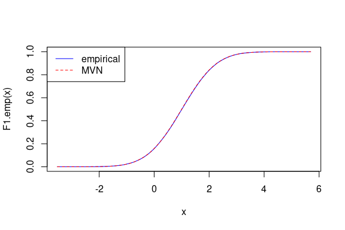

```r
X1.emp <- marginal(emp, 1)
F1.emp <- cdf(X1.emp)
curve(F1.emp(x), from = infimum(sup(X1.emp)), to = supremum(sup(X1.emp)), col = "blue", lty = 1)
X1 <- marginal(M, 1)
F1 <- cdf(X1)
curve(F1(x), from = infimum(sup(X1.emp)), to = supremum(sup(X1.emp)), add = TRUE, col = "red", lty = 2)
legend("topleft", legend = c("empirical", "MVN"), col = c("blue", "red"), lty = c(1, 2))
```

Given the sample size, the empirical distribution’s CDF is essentially the same as the MVN’s CDF (they’re right on top of each other). Let’s zoom in much closer so we can ee that the empirical CDF is a step function:

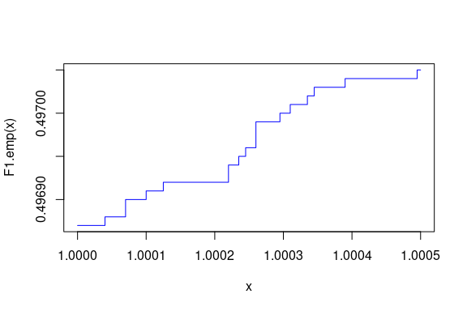

```r
curve(F1.emp(x), from = 1, to = 1.0005, col = "blue", lty = 1, type = "s")
```

Let’s compute some expectations of $X_1$:

```r
cat("E(X1) = ", expectation(X1, \(x) x), "( expected ", mean(X1), ")\n",
"Var(X1) = ", expectation(X1, \(x)
  (x - expectation(X1, \(x) x))^2), "( expected ", vcov(X1), ")\n",
"Skewness(X1) = ", expectation(X1, function(x)
  (x - expectation(X1, \(x) x))^3) / expectation(X1, \(x) x)^3, "( expected 0 )\n",
"E(X^2) = ", expectation(X1, \(x) x^2), "( expected ", vcov(X1) + mean(X1)^2, ")")
```

```
#> E(X1) =  1 ( expected  1 )
#>  Var(X1) =  1 ( expected  1 )
#>  Skewness(X1) =  -0.000000000000341 ( expected 0 )
#>  E(X^2) =  2 ( expected  2 )
```

Let’s show a scatter plot of the joint distribution of $X_2$ and $X_4$:

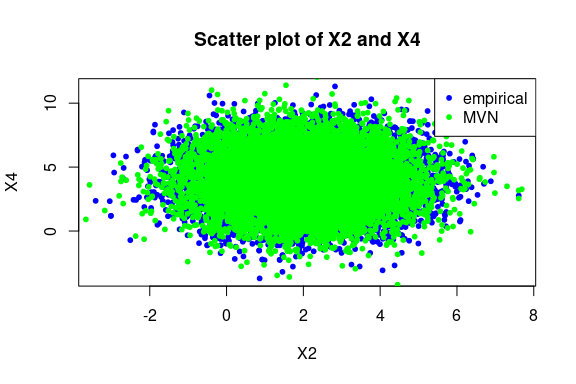

```r
dataX2X4.emp <- sampler(marginal(emp, c(2, 4)))(10000)
dataX2X4.mvn <- sampler(marginal(M, c(2, 4)))(10000)

# scatter plot a 2d sample. use xlab and ylab to label the axes
plot(dataX2X4.emp[,1], dataX2X4.emp[,2], pch = 20, col = "blue", xlab = "X2", ylab = "X4")
# overlay in green the MVN data
points(dataX2X4.mvn[,1], dataX2X4.mvn[,2], pch = 20, col = "green")
legend("topright", legend = c("empirical", "MVN"), col = c("blue", "green"), pch = c(20, 20))
title("Scatter plot of X2 and X4")
```

Let’s look at the MVN’s multivariate CDF:

```r
cdf(M)(c(1,2,3,4,0))
```

```
#> [1] 0.000792
```

Now we show the mean of the conditional distribution, $X | X_1 + X_2 < 0$:

```r
mean(conditional(emp, function(x) x[1] + x[2] < 0))
```

```
#> [1] -0.250 -0.457  2.999  3.984  4.952
```

```r
mean(conditional(M, function(x) x[1] + x[2] < 0))
```

```
#> [1] -0.127 -0.573  2.993  3.987  5.163
```

I didn’t do the analysis of what this distribution’s mean should theoretically be, if it’s even practical to derive, but it doesn’t look unreasonble. We see that the mean of the first two components are negative, which makes sense: the sum of the first two components is negative, so the mean of the first two components should be negative.